# Week 4 Lab

Audrey Omidsalar

9/17/2021

## 1. Read in the Data

```r
if (!file.exists("met_all.gz"))
  download.file(
    url = "https://raw.githubusercontent.com/USCbiostats/data-science-data/master/02_met/met_all.gz",
    destfile = "met_all.gz",
    method   = "libcurl",
    timeout  = 60
    )
met <- data.table::fread("met_all.gz")
```

## 2. Prepare the data

#### Remove temperatures less than -17C

```r
met <- met[temp>=-17]
summary(met)
```

```
##      USAFID            WBAN            year          month        day
##  Min.   :690150   Min.   :  116   Min.   :2019   Min.   :8   Min.   : 1
##  1st Qu.:720927   1st Qu.: 3705   1st Qu.:2019   1st Qu.:8   1st Qu.: 8
##  Median :722720   Median :13841   Median :2019   Median :8   Median :16
##  Mean   :723095   Mean   :29496   Mean   :2019   Mean   :8   Mean   :16
##  3rd Qu.:725090   3rd Qu.:54768   3rd Qu.:2019   3rd Qu.:8   3rd Qu.:24
##  Max.   :726813   Max.   :94998   Max.   :2019   Max.   :8   Max.   :31
##
##       hour            min             lat             lon
##  Min.   : 0.00   Min.   : 0.00   Min.   :24.55   Min.   :-124.29
##  1st Qu.: 6.00   1st Qu.:20.00   1st Qu.:33.98   1st Qu.: -98.02
##  Median :11.00   Median :48.00   Median :38.37   Median : -91.74
##  Mean   :11.46   Mean   :39.23   Mean   :37.97   Mean   : -92.14
##  3rd Qu.:17.00   3rd Qu.:55.00   3rd Qu.:41.96   3rd Qu.: -82.99
##  Max.   :23.00   Max.   :59.00   Max.   :48.94   Max.   : -68.31
##
##       elev           wind.dir      wind.dir.qc        wind.type.code
##  Min.   : -13.0   Min.   :  3      Length:2317212     Length:2317212
##  1st Qu.: 101.0   1st Qu.:120      Class :character   Class :character
##  Median : 252.0   Median :180      Mode  :character   Mode  :character
##  Mean   : 415.1   Mean   :185
##  3rd Qu.: 400.0   3rd Qu.:260
##  Max.   :9999.0   Max.   :360
##                   NA's   :732171
##     wind.sp       wind.sp.qc          ceiling.ht    ceiling.ht.qc
##  Min.   : 0.00   Length:2317212     Min.   :    0   Min.   :1.000
##  1st Qu.: 0.00   Class :character   1st Qu.: 3048   1st Qu.:5.000
##  Median : 2.10   Mode  :character   Median :22000   Median :5.000
##  Mean   : 2.46                      Mean   :16171   Mean   :4.945
##  3rd Qu.: 3.60                      3rd Qu.:22000   3rd Qu.:5.000
##  Max.   :36.00                      Max.   :22000   Max.   :9.000
##  NA's   :31743                      NA's   :73442
##  ceiling.ht.method    sky.cond            vis.dist      vis.dist.qc
##  Length:2317212     Length:2317212     Min.   :     0   Length:2317212
##  Class :character   Class :character   1st Qu.: 16093   Class :character
##  Mode  :character   Mode  :character   Median : 16093   Mode  :character
##                                        Mean   : 14924
##                                        3rd Qu.: 16093
##                                        Max.   :160000
##                                        NA's   :33674
```

[output cut: 9 more lines]

```
##  Min.   :-37.20   Length:2317212     Min.   : 960.5    Min.   :1.000
##  1st Qu.: 13.80   Class :character   1st Qu.:1011.8    1st Qu.:5.000
##  Median : 18.10   Mode  :character   Median :1014.1    Median :9.000
##  Mean   : 17.02                      Mean   :1014.2    Mean   :7.696
##  3rd Qu.: 21.70                      3rd Qu.:1016.4    3rd Qu.:9.000
##  Max.   : 36.00                      Max.   :1059.9    Max.   :9.000
##  NA's   :6295                        NA's   :1606788
##        rh
##  Min.   :  0.833
##  1st Qu.: 55.790
##  Median : 76.554
##  Mean   : 71.641
##  3rd Qu.: 90.629
##  Max.   :100.000
##  NA's   :6295
```

#### After checking the data we should make the appropriate modifications.

Replace 9999 in elevation with NA

```r
met[elev == 9999.0, elev := NA]
```

#### Generate a date variable using the as.Date() function

```r
met[, ymd := as.Date(paste(year, month, day, sep = "-"))]
met
```

```
##          USAFID  WBAN year month day hour min    lat      lon elev wind.dir
##       1: 690150 93121 2019     8   1    0  56 34.300 -116.166  696      220
##       2: 690150 93121 2019     8   1    1  56 34.300 -116.166  696      230
##       3: 690150 93121 2019     8   1    2  56 34.300 -116.166  696      230
##       4: 690150 93121 2019     8   1    3  56 34.300 -116.166  696      210
##       5: 690150 93121 2019     8   1    4  56 34.300 -116.166  696      120
##      ---
## 2317208: 726813 94195 2019     8  31   19  56 43.650 -116.633  741       70
## 2317209: 726813 94195 2019     8  31   20  56 43.650 -116.633  741       NA
## 2317210: 726813 94195 2019     8  31   21  56 43.650 -116.633  741       10
## 2317211: 726813 94195 2019     8  31   22  56 43.642 -116.636  741       10
## 2317212: 726813 94195 2019     8  31   23  56 43.642 -116.636  741       40
##          wind.dir.qc wind.type.code wind.sp wind.sp.qc ceiling.ht ceiling.ht.qc
##       1:           5              N     5.7          5      22000             5
##       2:           5              N     8.2          5      22000             5
```

[output cut: 45 more lines]

#### Using the data.table::week function, keep the observations of the first week of the month.

This outputs the week numbers according to the column with the date variable, ymd, set earlier. Week 31 is the first week of August.

```r
met[,table(week(ymd))]
```

```
##
##     31     32     33     34     35
## 297260 521605 527924 523847 446576
```

#### Subset the dataset to keep only the first week of the month.

```r
met <- met[week(ymd) == 31]
met
```

```
##         USAFID  WBAN year month day hour min   lat      lon elev wind.dir
##      1: 690150 93121 2019     8   1    0  56 34.30 -116.166  696      220
##      2: 690150 93121 2019     8   1    1  56 34.30 -116.166  696      230
##      3: 690150 93121 2019     8   1    2  56 34.30 -116.166  696      230
##      4: 690150 93121 2019     8   1    3  56 34.30 -116.166  696      210
##      5: 690150 93121 2019     8   1    4  56 34.30 -116.166  696      120
##     ---
## 297256: 726813 94195 2019     8   4   19  56 43.65 -116.633  741       40
## 297257: 726813 94195 2019     8   4   20  56 43.65 -116.633  741       50
## 297258: 726813 94195 2019     8   4   21  56 43.65 -116.633  741       30
## 297259: 726813 94195 2019     8   4   22  56 43.65 -116.633  741       NA
## 297260: 726813 94195 2019     8   4   23  56 43.65 -116.633  741       NA
##         wind.dir.qc wind.type.code wind.sp wind.sp.qc ceiling.ht ceiling.ht.qc
##      1:           5              N     5.7          5      22000             5
##      2:           5              N     8.2          5      22000             5
```

[output cut: 45 more lines]

#### Compute the mean by station of the variables temp, rh, wind.sp, vis.dist, dew.point, lat, lon, and elev. Creating a new datatable met_avg that stores these values.

```r
met_avg <- met[, .(
  temp     = mean(temp, na.rm=TRUE),
  rh       = mean(rh, na.rm=TRUE),
  wind.sp  = mean(wind.sp, na.rm=TRUE),
  vis.dist = mean(vis.dist, na.rm=TRUE),
  dew.point= mean(dew.point, na.rm=TRUE),
  lat      = mean(lat, na.rm=TRUE),
  lon      = mean(lon, na.rm=TRUE),
  elev     = mean(elev, na.rm=TRUE), USAFID
), by = "USAFID"]
met_avg
```

```
##       USAFID     temp       rh  wind.sp vis.dist dew.point      lat       lon
##    1: 690150 33.79167 14.93604 3.932292 16042.72  2.641667 34.29992 -116.1659
##    2: 720110 30.95139 51.18987 1.785069 15936.55 18.763889 30.78400  -98.6620
##    3: 720113 23.65403 57.09799 1.476344 16080.02 13.861828 42.54300  -83.1780
##    4: 720120 25.59172 88.10970 1.580473 15402.63 23.378698 32.21746  -80.6998
##    5: 720137 22.39965 65.79964 0.937500 16059.47 14.828125 41.42500  -88.4190
##   ---
## 1572: 726777 24.16040 61.50894 4.110891 15885.87 15.095050 46.35760 -104.2504
## 1573: 726797 20.29831 58.04065 3.594915 16024.82 10.366102 45.78772 -111.1598
## 1574: 726798 22.05372 46.65441 4.643802 15268.41  8.837168 45.69800 -110.4400
## 1575: 726810 27.22389 33.18024 2.459459 16079.83  8.303540 43.56700 -116.2390
## 1576: 726813 26.62500 41.57813 2.636458 16059.48 11.586458 43.64983 -116.6331
##            elev USAFID
##    1:  694.5208 690150
##    2:  336.0000 720110
##    3:  222.0000 720113
##    4:    6.0000 720120
##    5:  178.0000 720137
##   ---
## 1572:  906.0000 726777
## 1573: 1356.1780 726797
## 1574: 1408.0000 726798
## 1575:  873.8584 726810
## 1576:  741.0000 726813
```

#### Create a region variable for Northwest, Southwest, Northeast, Southeast based on lon = -98.00 and lat = 39.71 degrees. Count number of observations of each region variable.

```r
met_avg[lat >= 39.71 & lon <= -98, region := "Northwest"]
met_avg[lat < 39.71 & lon <= -98, region := "Southwest"]
met_avg[lat >= 39.71 & lon > -98, region := "Northeast"]
met_avg[lat < 39.71 & lon > -98, region := "Southeast"]
met_avg[, table(region, useNA="always")]
```

```
## region
## Northeast Northwest Southeast Southwest      <NA>
##       484       146       649       297         0
```

#### Create a categorical variable for elevation

```r
met_avg[,elev_cat := fifelse(elev > 252, "high", "low")]
##Deleting extra "USAFID" column 1
met_avg <- met_avg[, -1]
met_avg
```

```
##           temp       rh  wind.sp vis.dist dew.point      lat       lon
##    1: 33.79167 14.93604 3.932292 16042.72  2.641667 34.29992 -116.1659
##    2: 30.95139 51.18987 1.785069 15936.55 18.763889 30.78400  -98.6620
##    3: 23.65403 57.09799 1.476344 16080.02 13.861828 42.54300  -83.1780
##    4: 25.59172 88.10970 1.580473 15402.63 23.378698 32.21746  -80.6998
##    5: 22.39965 65.79964 0.937500 16059.47 14.828125 41.42500  -88.4190
##   ---
## 1572: 24.16040 61.50894 4.110891 15885.87 15.095050 46.35760 -104.2504
## 1573: 20.29831 58.04065 3.594915 16024.82 10.366102 45.78772 -111.1598
## 1574: 22.05372 46.65441 4.643802 15268.41  8.837168 45.69800 -110.4400
## 1575: 27.22389 33.18024 2.459459 16079.83  8.303540 43.56700 -116.2390
## 1576: 26.62500 41.57813 2.636458 16059.48 11.586458 43.64983 -116.6331
##            elev USAFID    region elev_cat
##    1:  694.5208 690150 Southwest     high
##    2:  336.0000 720110 Southwest     high
##    3:  222.0000 720113 Northeast      low
##    4:    6.0000 720120 Southeast      low
##    5:  178.0000 720137 Northeast      low
##   ---
## 1572:  906.0000 726777 Northwest     high
## 1573: 1356.1780 726797 Northwest     high
## 1574: 1408.0000 726798 Northwest     high
## 1575:  873.8584 726810 Northwest     high
## 1576:  741.0000 726813 Northwest     high
```

## 3. Use geom_violin to examine the wind speed and dew point temperature by region

#### Wind speed by region

Wind speed is lower in the eastern regions. The northeast region seems to have the largest range, as well as an outlier.

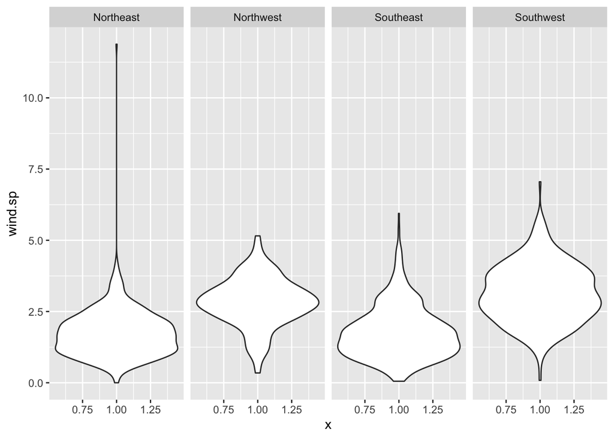

```r
met_avg[!is.na(region)] %>%
  ggplot(met_avg, mapping=aes(x=1, y=wind.sp)) +
  geom_violin() +
  facet_grid(~ region)
```

#### Dew point by region

The lowest dew points as well as the largest ranges in dew point are found in the western regions.

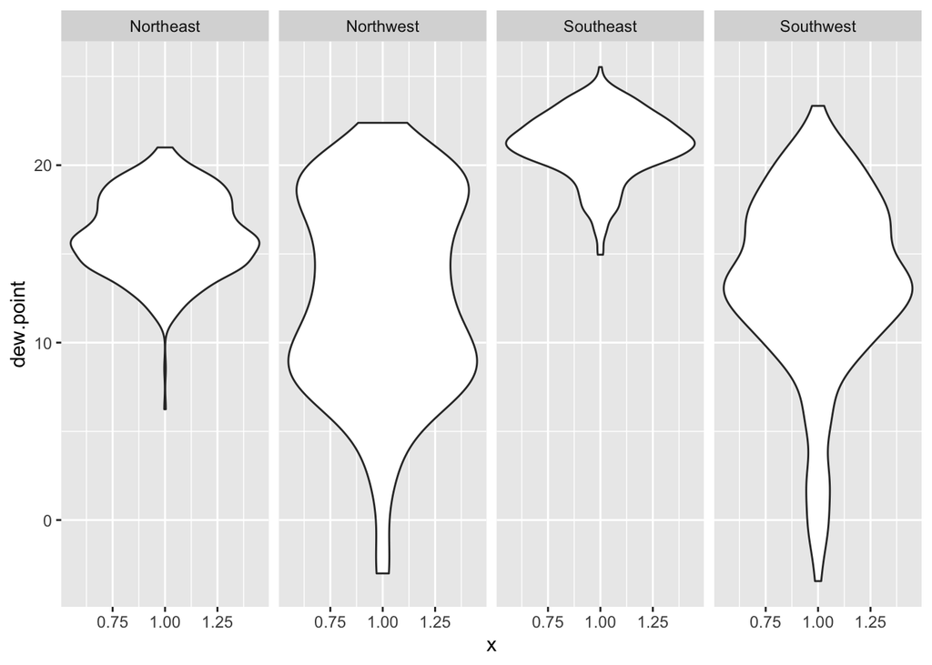

```r
met_avg[!is.na(region)] %>%
  ggplot(met_avg, mapping=aes(x=1, y=dew.point)) +
  geom_violin() +
  facet_grid(~ region)
```

## 4. Use geom_jitter with stat_smooth to examine the association between dew point temperature and wind speed by region

The eastern regions seem to have a slightly positive association between dew point temperature and wind speed, as seen by the linear regression lines having a slightly positive slope. The linear regression lines for the western regions have slopes close to zero.

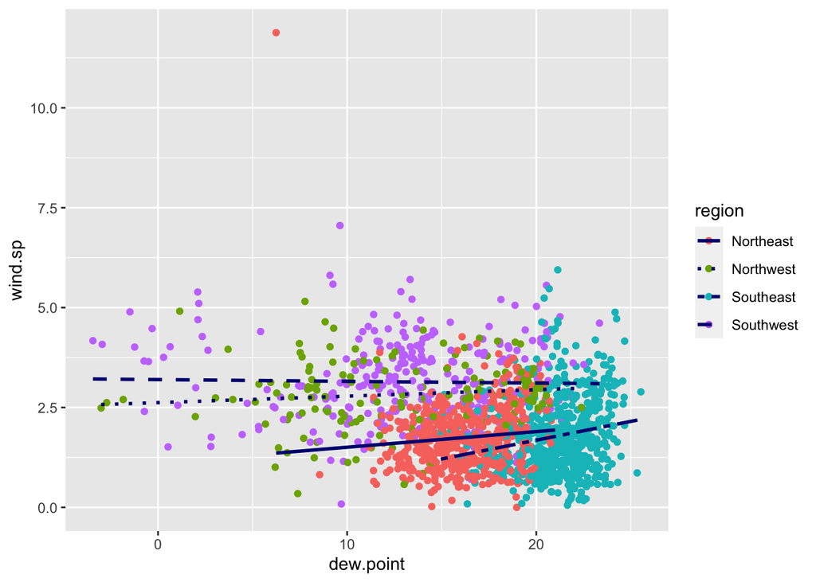

```r
met_avg[!is.na(dew.point) & !is.na(wind.sp)] %>%
  ggplot(mapping=aes(x=dew.point, y = wind.sp, color=region, linetype=region)) +
  geom_jitter() +
  stat_smooth(method=lm, se=FALSE, color="navy") +
  scale_linetype_manual(values=c("solid","dotted", "twodash", "dashed"))
```

## 5. Use geom_bar to create barplots of the weather stations by elevation category coloured by region

The northeast has a similar number of weather stations in high and low elevations, as opposed to southeast region which has more weather stations at low elevations as well as the northwest and southwest regions which both have fewer weather stations at low elevations.

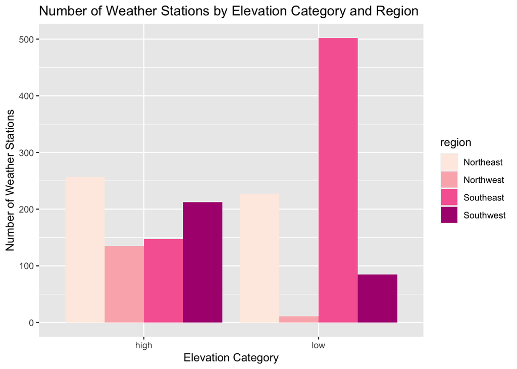

```r
met_avg[!is.na(USAFID)] %>%
  ggplot(mapping=aes(x=elev_cat, fill=region)) +
  geom_bar(position="dodge") +
  labs(title = "Number of Weather Stations by Elevation Category and Region", x  = "Elevation Category", y = "Number of Weather Stations") +
  scale_fill_brewer(palette = "RdPu")
```

## 6. Use stat_summary to examine mean dew point and wind speed by region with standard deviation error bars

#### Mean Wind speed by region

The northeast and southeast regions have similar average wind speeds to each other, and the northwest and southwest regions have similar average wind speeds to each other. The eastern regions have lower average wind speeds compared to the western regions.

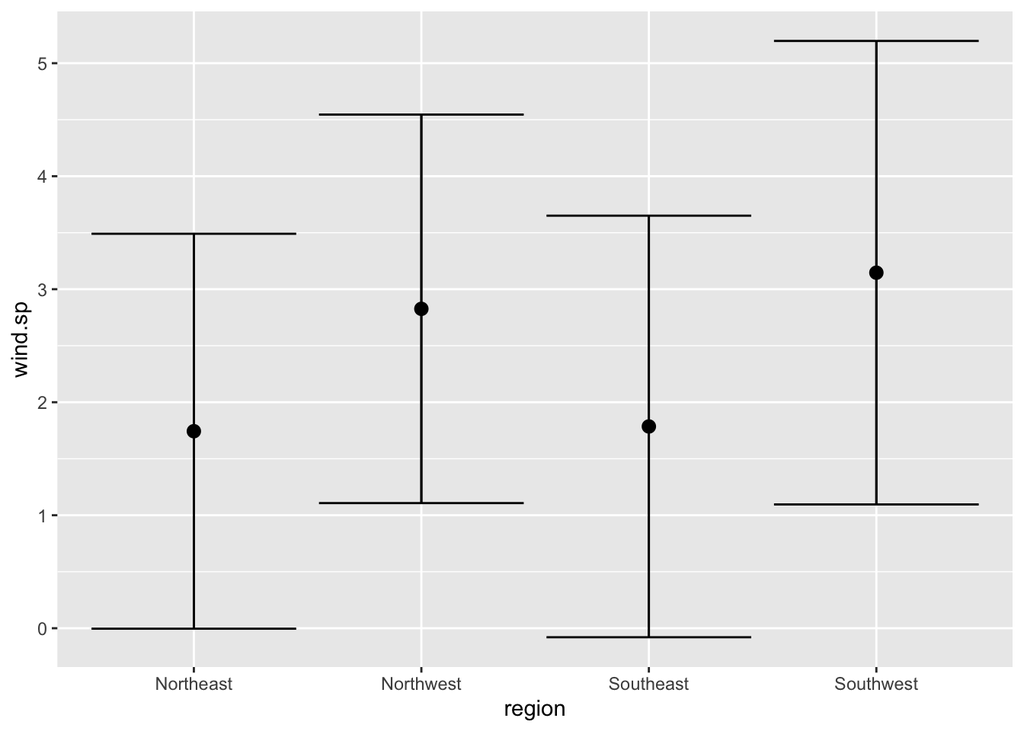

```r
ggplot(met_avg[!is.na(wind.sp)], mapping=aes(x=region, y=wind.sp)) +
  stat_summary(fun.data = "mean_sdl") +
  stat_summary(fun.data = "mean_sdl", geom="errorbar")
```

#### Mean dew point by region

The northwest and southwest regions have similar average dew points. The southeast has the smallest standard error and highest average dew point. Average dew point temperature is higher in eastern regions than in western regions.

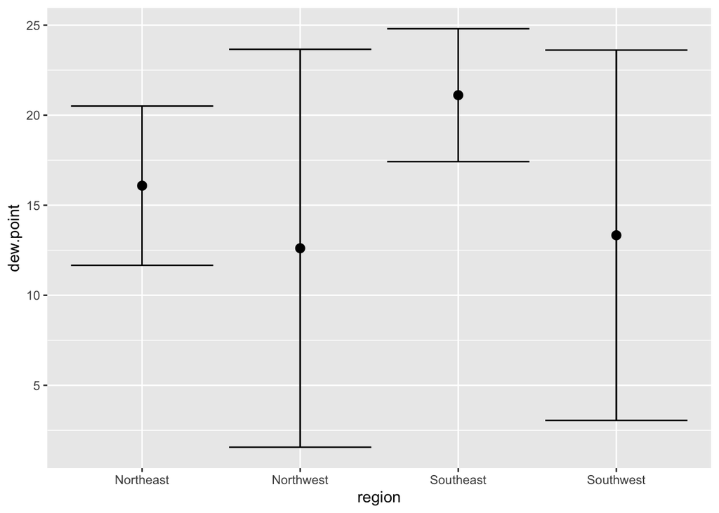

```r
ggplot(met_avg[!is.na(dew.point)], mapping=aes(x=region, y=dew.point)) +
  stat_summary(fun.data = "mean_sdl") +
  stat_summary(fun.data = "mean_sdl", geom="errorbar")
```

## 7. Make a map showing the spatial trend in relative h in the US

Relative humidity temperature tends to increase as we move from western to eastern US.

```r
met_avg2 <- met_avg[!is.na(rh)]
temp.pal <- colorNumeric(c('darkgreen', 'goldenrod', 'brown'), domain = met_avg2$rh)

leaflet(met_avg2) %>%
  addProviderTiles('CartoDB.Positron') %>%
  addCircles(lat = ~lat, lng=~lon,
     label = ~paste0(round(rh,2), ' rh'), color = ~ temp.pal(rh),
     opacity = 1, fillOpacity = 1, radius = 500) %>%
  addMarkers(lat = ~met_avg2[rank(-rh) <= 10, lat], lng = ~met_avg2[rank(-rh) <= 10, lon]) %>%
  addLegend('bottomleft', pal=temp.pal, values=met_avg2$rh,
          title='Temperature, C', opacity=1)
```

[interactive chart not shown]

## 8. Use a ggplot extension: ggpubr

ggpubr can be used to create publication-ready plots, including ones that have p-values included. This graph is a boxplot of relative humidity per region, with p values across groups added.

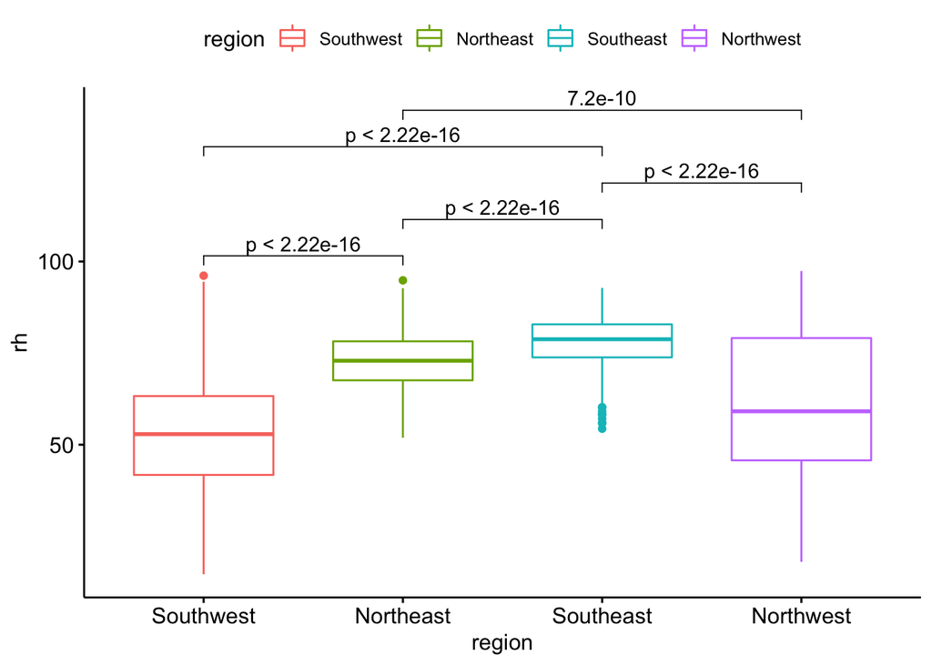

```r
p <- ggboxplot(met_avg2, x = "region", y = "rh", color="region")
my_comparisons <- list( c("Southwest", "Northeast"),c("Northeast", "Southeast"), c("Southeast", "Northwest"), c("Southwest", "Southeast"), c("Northeast", "Northwest"))
p + stat_compare_means(comparisons = my_comparisons) # Add pairwise comparisons p-value
```